# HBHC - 4.3.1 - Lake Hawdon abundance models

Thomas Prowse - thomas.prowse@adelaide.edu.au

15/12/2021

This R script reads the selected waterbird abundance model for Lake Hawdon South which was presented in report 4.3.1 of the Healthy Coorong, Healthy Basin Program. The script also generates and saves model outputs as response curve plots, and extrapolates the model fitted using data from Lake Hawdon South to two water management scenarios (current and planned) for Lake Hawdon North.

Generalised additive models were to model the abudance of 6 shorebirds (i.e. Common Greenshank, Curlew sandpiper, Red-capped plover, Red-necked avocet, Red-necked Stint and Sharp-tailed Sandpiper) simultaneously. Based on cross-validation, a simple model structure was selected (~ (1|Species) + Area, where ‘Area’ is the area of habitat within the 0-10 cm depth range). Please refer to the 4.3.1 report for more details about the methods and analysis of this dataset.

Please set the R working directory to Lake Hawdon North folder before running the R script “LakeHawdonNorth.R”.

# Load packages

```r
# If any of these packages are not installed, use install.packages("package name") before uploading them

rm(list=ls())
library(raster)
library(mgcv)
library(ggplot2)
library(lubridate)
library(scales)
library(reshape2)
```

# Load models and data

## Load abundance model

```r
fit <- readRDS('Best model based on NRMSE.rds')
```

*fit* is the selected GAM model for the six shorebird species.

## Load waterbird data

```r
waterbirds <- readRDS('waterbirds.rds')
```

*waterbirds* is a data frame of waterbird abundance counts, in a format suitable for plotting along with the response curves generated below.

## Load scenario data

```r
scenarios <- readRDS('scenarios.rds')
```

*scenarios* is a data frame containing the expected area of habitat within the 0-10 cm depth range in Lake Hawdon North for each day of the year, under current management and target management following construction of a regulator. These scenarios were provided by Ben Taylor (Nature Glenelg Trust) and reported in “Taylor, B. (2020) Restoration Feasibility Assessment of Lake Hawdon North. Nature Glenelg Trust, Mount Gambier, South Australia.”

# Waterbird response models

## Generate predictions from the model and merge with the waterbirds data

```r
# Generate predictions from the model
species.nms <- unique(waterbirds$Species)
pred.df <- expand.grid(list(Species=sort(unique(species.nms)),
                            Area=seq(min(waterbirds$Area[waterbirds$Class=='Response Curve']),
                                     max(waterbirds$Area[waterbirds$Class=='Response Curve']),                                      length.out = 100)))
predictions <- predict(fit, newdata=pred.df, re.form=NULL, se.fit=T)
pred.df$y <- NA
pred.df$est <- exp(predictions$fit)
pred.df$lcl <- exp(predictions$fit-1.96*predictions$se.fit)
pred.df$ucl <- exp(predictions$fit+1.96*predictions$se.fit)
pred.df$Class <- 'Response Curve'

# Truncate upper confidence intervals to improve visualisation
pred.df$ucl <- ifelse(pred.df$Species=="Common.greenshank" & pred.df$ucl>250,250,pred.df$ucl)
pred.df$ucl <- ifelse(pred.df$Species=="Curlew.sandpiper" & pred.df$ucl>50,50,pred.df$ucl)
pred.df$ucl <- ifelse(pred.df$Species=="Red.capped.plover" & pred.df$ucl>250,250,pred.df$ucl)
pred.df$ucl <- ifelse(pred.df$Species=="Red.necked.avocet" & pred.df$ucl>5,5,pred.df$ucl)
pred.df$ucl <- ifelse(pred.df$Species=="Red.necked.stint" & pred.df$ucl>2000,2000,pred.df$ucl)
pred.df$ucl <- ifelse(pred.df$Species=="Sharp.tailed.sandpiper" & pred.df$ucl>20000,20000,pred.df$ucl)

# Merge with the raw waterbird data and fix species names
df <- rbind(waterbirds, pred.df)
df$Species <- as.character(factor(df$Species))
df$Species <- gsub('\\.',' ',df$Species)
df$Species <- gsub('Red capped','Red-capped',df$Species)
df$Species <- gsub('Red necked','Red-necked',df$Species)
df$Species <- gsub('Sharp tailed','Sharp-tailed',df$Species)
```

## Plot response curves and save

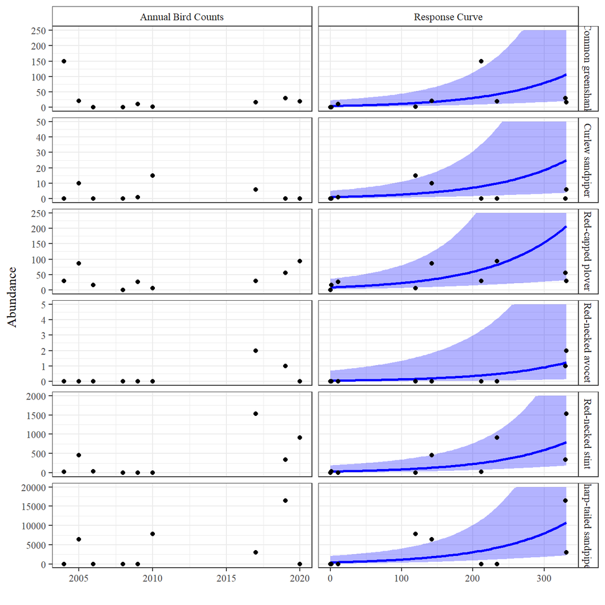

```r
(p1 <- ggplot(df, aes(Area, y)) + facet_grid(Species~Class, scales='free') +
    xlab('') + ylab('Abundance') +
    geom_ribbon(aes(ymin=lcl, ymax=ucl), data=subset(df, !is.na(lcl) & Class=='Response Curve'),
                fill='blue', alpha=0.3) +
    geom_line(aes(Area, est), data=subset(df, !is.na(lcl) & Class=='Response Curve'), colour='blue', size=1) +
    geom_point() +
    theme_bw() +
    theme(text=element_text(family='serif'),strip.background = element_rect(fill=NA)) +
    scale_color_manual(values=c('orangered3','royalblue2')))
```

```r
dir.create('figures')
pdf('figures/Response curves.pdf', width=6, height=8.2)
print(p1)
dev.off()
```

# Predicted waterbird responses under different water-mangement scenarios in Lake Hawdon North

## Plot current and target shallow-water scenarios for Lake hawdon North

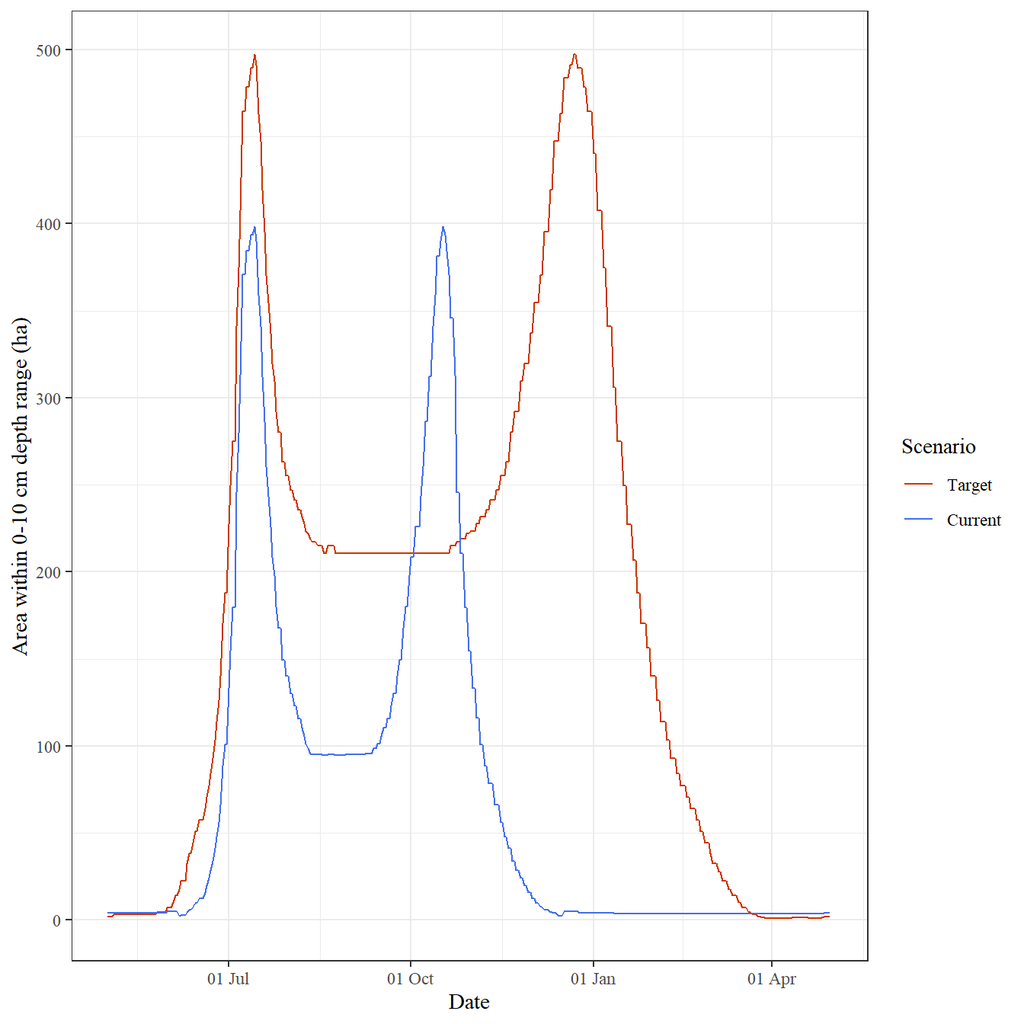

```r
# melt scenario data into format suitable for plotting
scenarios <- melt(scenarios, id.vars=1, variable.name='Scenario', value.name='Area')

## plot out the scenarios
(p2 <- ggplot(scenarios, aes(Date, Area, group=Scenario, colour=Scenario)) +
  geom_line() +
  scale_x_date(labels=date_format("%d %b"),limits = as.Date(c('2021-05-01','2022-05-01'))) +
  xlab('Date') + ylab('Area within 0-10 cm depth range (ha)') + theme_bw() +
    theme(text=element_text(family='serif'),strip.background = element_rect(fill=NA)) +
    scale_color_manual(values=c('orangered3','royalblue2')))
```

```r
pdf('figures/Shallow-water scenario for LHN.pdf', width=5, height=3)
print(p2)
dev.off()
```

## Predict bird abundance under these water level scenarios

```r
species.scen <- NULL
for (i in 1:length(species.nms)) {
  myscen <- data.frame(scenarios, Species=species.nms[i])
  species.scen <- rbind(species.scen , myscen)
}
species.scen$Species <- factor(species.scen$Species, levels=levels(waterbirds$Species))
species.scen$est <- predict(fit, newdata=species.scen, type='response')
species.scen$Species <- gsub('\\.',' ',species.scen$Species)
species.scen$Species <- gsub('Red capped','Red-capped',species.scen$Species)
species.scen$Species <- gsub('Red necked','Red-necked',species.scen$Species)
species.scen$Species <- gsub('Sharp tailed','Sharp-tailed',species.scen$Species)
species.scen <- subset(species.scen, Date>=as.Date('2021-10-01') & Date<=as.Date('2022-4-01'))

# add totals for all 6 species
totals <- aggregate(cbind(Area,est) ~ Date + Scenario, species.scen, sum)
totals <- data.frame(totals[,1:3],Species='Total (all 6 species)',totals[,4,drop=F])
species.scen <- rbind(species.scen, totals)
```

Note that different shallow-water time-series could be used above to explore waterbird responses under different management scenarios.

## Plot out bird responses to scenarios

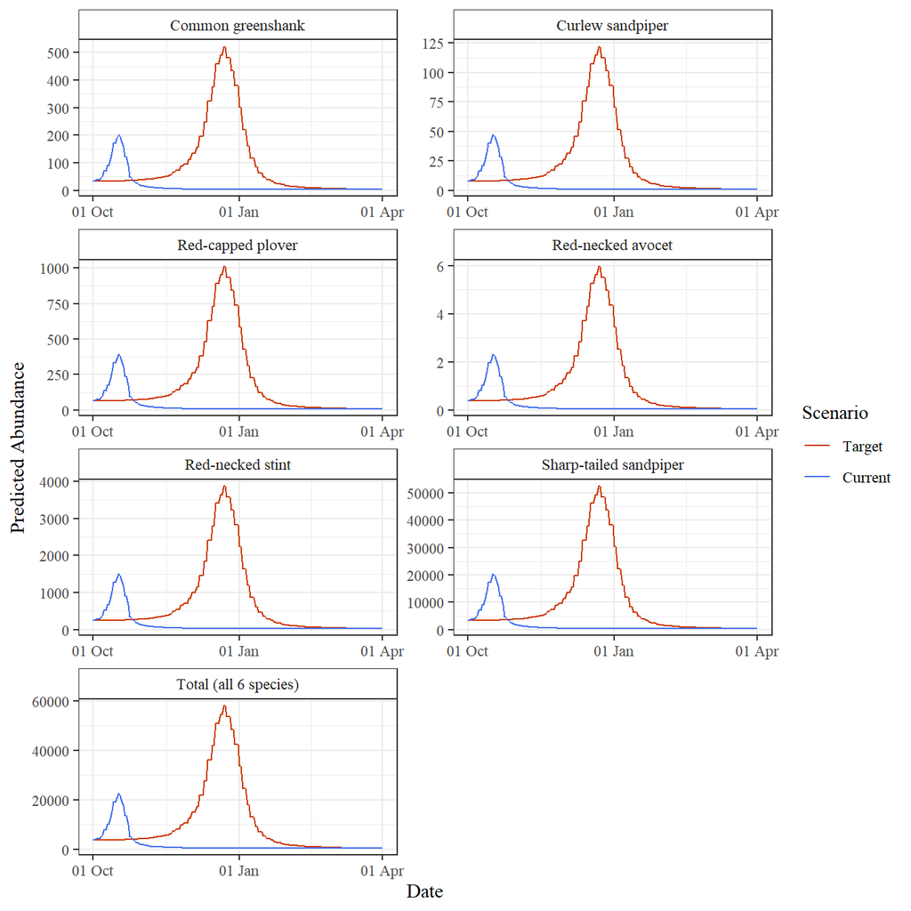

```r
(p3 <- ggplot(species.scen, aes(Date, est, group=Scenario, colour=Scenario)) +
    geom_line() + facet_wrap(~Species, scales='free', ncol=2) +
    scale_x_date(labels=date_format("%d %b"),limits = as.Date(c('2021-10-01','2022-04-01'))) +
    xlab('Date') + ylab('Predicted Abundance') + theme_bw() +
    theme(text=element_text(family='serif'),strip.background = element_rect(fill=NA)) +
    scale_color_manual(values=c('orangered3','royalblue2')))
```

```r
pdf('figures/Predictions under LHN scenarios.pdf', width=6, height=8.2)
print(p3)
dev.off()
```